# Cox vs GLM Approximation: Null Operating Characteristics

- Show All Code
- Hide All Code
- View Source

Threshold Calibration for the GBSG Survival DGM

Author

Larry F. Leon

Published

April 8, 2026

# 1 Introduction

Leon et al. (2024, Section 2.1) approximate the per-subgroup detection probability as:

$$P_1(c_1, c_2; d, \theta) =
P(W_1 + W_2 \ge 2\log c_1, \;\min(W_1, W_2) \ge \log c_2)
\tag{3}$$

with $W_1, W_2 \stackrel{\text{iid}}{\sim} N(\log\theta, 8/d)$.

This document focuses on **null operating characteristics** for the GBSG survival DGM: we evaluate how the false-positive rate (FPR) varies across a grid of $(c_1, c_2)$ threshold pairs to identify the region where the procedure-level FPR is at most 10–12%.

We compare:

- **(B)** GLM approximation (per-subgroup $P_1$ via `compute_detection_probability_glm()`)
- **(C)** Cox ForestSearch simulation
- **(A)** Poisson+offset ForestSearch simulation
- **$L_{\text{eff}}$ correction**: $1 - (1 - P_1)^{L_{\text{eff}}}$

All simulations are under $H_0$ (uniform treatment effect, no subgroup heterogeneity).

# 2 Setup

```r
library(forestsearch)
library(weightedsurv)
library(data.table)
library(survival)
library(ggplot2)
library(patchwork)
library(gt)
library(foreach)
library(doFuture)
library(future)

# -- Safe foreach result collection -------------------------------------------
# Replaces .errorhandling = "remove" (which silently drops failures)
# with .errorhandling = "pass" + post-hoc separation of errors from results.
collect_results <- function(raw_list, label = "") {
  is_err <- vapply(raw_list, inherits, logical(1), "error")
  n_failed <- sum(is_err)
  if (n_failed > 0) {
    err_msgs <- vapply(raw_list[is_err], conditionMessage, character(1))
    warning(sprintf("%s%d of %d tasks failed.",
        if (nzchar(label)) paste0(label, ": ") else "",
        n_failed, length(raw_list)))
    message("  First errors:\n    ",
        paste(head(unique(err_msgs), 3), collapse = "\n    "))
  }
  good <- raw_list[!is_err]
  if (length(good) == 0) {
    result <- NULL
  } else if (requireNamespace("data.table", quietly = TRUE)) {
    result <- data.table::rbindlist(good, use.names = TRUE, fill = TRUE)
    result <- as.data.frame(result)
  } else {
    result <- do.call(rbind, good)
  }
  attr(result, "n_failed") <- n_failed
  attr(result, "n_total") <- length(raw_list)
  result
}


# L_eff save/load helpers
#source(here::here("../R", "leff_calibration_io.R"))
plan(multisession, workers = n_workers)
cat("Using", n_workers, "parallel workers\n")
```

```
#> Using 121 parallel workers
```

```r
cat("H0 sims per config:", nsims_null, "\n")
```

```
#> H0 sims per config: 20
```

```r
timings <- list()
t_vignette_start <- proc.time()
```

# 3 Null DGM

```r
t0 <- proc.time()[3]

dgm_null <- setup_gbsg_dgm(model = "null", k_treat = 1.0, verbose = TRUE)
```

```
#> === GBSG DGM Creation (Aligned) ===
```

```
#> Model type: null
```

```
#> Effect modifiers: k_treat = 1.000, k_inter = 1.000, k_z3 = 1.000
```

```
#> Sample size: 686
```

```
#> Events: 299 (43.6%)
```

```
#> Harm subgroup size: 0 (0.0%)
```

```
#> ER threshold (z1_quantile = 0.25): 8.0
```

```
#>
#> --- Original AFT Coefficients ---
```

```
#> sigma (scale): 0.7151
```

```
#> mu (intercept): 4.4590
```

```
#> gamma coefficients:
```

```
#>   treat: 0.3034
```

```
#>   z1: -0.0411
```

```
#>   z2: -0.0393
```

```
#>   z3: -0.0118
```

```
#>   z4: 0.2464
```

```
#>   z5: -0.3234
```

```
#>
#> --- Modified AFT Coefficients ---
```

```
#> gamma['treat']: 0.3034 -> 0.3034 (k_treat = 1.000)
```

```
#> gamma['z3']: -0.0118 -> -0.0118 (k_z3 = 1.000)
```

```
#>
#> --- Hazard Ratios (Stacked Potential Outcomes) ---
```

```
#> HR (overall/causal): 0.7223
```

```
#> HR (harm subgroup, H): NA
```

```
#> HR (complement, Hc): 0.7223
```

```
#>
#> --- Average Hazard Ratios (from loghr_po) ---
```

```
#> AHR (overall): 0.6543
```

```
#> AHR (harm subgroup, H): NA
```

```
#> AHR (complement, Hc): 0.6543
```

```r
cat("\nNull DGM:\n")
```

```
#>
#> Null DGM:
```

```r
cat("  HR(ITT):", round(dgm_null$hr_causal, 3), "\n")
```

```
#>   HR(ITT): 0.722
```

```r
cat("  AHR:", round(dgm_null$AHR, 3), "\n")
```

```
#>   AHR: 0.654
```

```r
timings$dgm <- proc.time()[3] - t0
```

# 4 Part I: Per-Subgroup Approximation

Instant calculations — no simulation required.

```r
# Shorthand wrapper for compute_detection_probability_glm()
p_detect_glm <- function(theta, d_eff, c1, c2) {
  compute_detection_probability_glm(
    theta = theta, d_eff = d_eff, c1 = c1, c2 = c2,
    effect_scale = "ratio", method = "monte_carlo"
  )
}
```

## 4.1 Approximation Across Threshold Pairs

```r
# Reference subgroup: n_H = n.min (from setup)
n_H_dgm <- n_min_val
d_dgm <- round(d_eff_survival(n_H_dgm, prop_cens))

approx_null <- expand.grid(c1 = c1_grid, c2 = c2_grid,
                            stringsAsFactors = FALSE)
approx_null <- approx_null[approx_null$c2 <= approx_null$c1, ]

approx_null$P1 <- mapply(function(c1v, c2v) {
  round(p_detect_glm(1.0, d_dgm, c1v, c2v), 4)
}, approx_null$c1, approx_null$c2)

gt(approx_null) |>
  tab_header(
    title = "Per-Subgroup P1(theta=1.0) by Threshold Pair",
    subtitle = sprintf("n(H)=%d, d=%d events, prop_cens=%.2f",
                        n_H_dgm, d_dgm, prop_cens)
  ) |>
  tab_style(style = cell_fill(color = "#E8F5E9"),
    locations = cells_body(columns = P1, rows = P1 <= 0.10)) |>
  tab_style(style = cell_fill(color = "#FFF9C4"),
    locations = cells_body(columns = P1,
      rows = P1 > 0.10 & P1 <= 0.15)) |>
  tab_source_note(
    "P1 is the per-subgroup probability.  Procedure-level FPR may differ."
  )
```

Per-subgroup P1(theta=1) across (c1,c2) pairs at n.min = 60

Per-Subgroup P1(theta=1.0) by Threshold Pair

n(H)=60, d=32 events, prop_cens=0.46

| c1 | c2 | P1 |
| --- | --- | --- |
| 1.00 | 0.90 | 0.3278 |
| 1.10 | 0.90 | 0.2919 |
| 1.15 | 0.90 | 0.2694 |
| 1.20 | 0.90 | 0.2455 |
| 1.25 | 0.90 | 0.2215 |
| 1.30 | 0.90 | 0.1980 |
| 1.40 | 0.90 | 0.1544 |
| 1.50 | 0.90 | 0.1177 |
| 1.00 | 0.95 | 0.2903 |
| 1.10 | 0.95 | 0.2668 |
| 1.15 | 0.95 | 0.2492 |
| 1.20 | 0.95 | 0.2295 |
| 1.25 | 0.95 | 0.2089 |
| 1.30 | 0.95 | 0.1884 |
| 1.40 | 0.95 | 0.1487 |
| 1.50 | 0.95 | 0.1145 |
| 1.00 | 1.00 | 0.2502 |
| 1.10 | 1.00 | 0.2390 |
| 1.15 | 1.00 | 0.2266 |
| 1.20 | 1.00 | 0.2113 |
| 1.25 | 1.00 | 0.1944 |
| 1.30 | 1.00 | 0.1770 |
| 1.40 | 1.00 | 0.1419 |
| 1.50 | 1.00 | 0.1106 |
| 1.10 | 1.05 | 0.2104 |
| 1.15 | 1.05 | 0.2030 |
| 1.20 | 1.05 | 0.1920 |
| 1.25 | 1.05 | 0.1788 |
| 1.30 | 1.05 | 0.1645 |
| 1.40 | 1.05 | 0.1342 |
| 1.50 | 1.05 | 0.1061 |
| 1.10 | 1.10 | 0.1804 |
| 1.15 | 1.10 | 0.1780 |
| 1.20 | 1.10 | 0.1716 |
| 1.25 | 1.10 | 0.1621 |
| 1.30 | 1.10 | 0.1510 |
| 1.40 | 1.10 | 0.1258 |
| 1.50 | 1.10 | 0.1010 |
| 1.15 | 1.15 | 0.1522 |
| 1.20 | 1.15 | 0.1502 |
| 1.25 | 1.15 | 0.1446 |
| 1.30 | 1.15 | 0.1368 |
| 1.40 | 1.15 | 0.1168 |
| 1.50 | 1.15 | 0.0954 |
| 1.20 | 1.20 | 0.1285 |
| 1.25 | 1.20 | 0.1266 |
| 1.30 | 1.20 | 0.1220 |
| 1.40 | 1.20 | 0.1070 |
| 1.50 | 1.20 | 0.0891 |
| 1.25 | 1.25 | 0.1077 |
| 1.30 | 1.25 | 0.1063 |
| 1.40 | 1.25 | 0.0965 |
| 1.50 | 1.25 | 0.0822 |

P1 is the per-subgroup probability. Procedure-level FPR may differ.

## 4.2 Per-Subgroup Approximation Heatmap

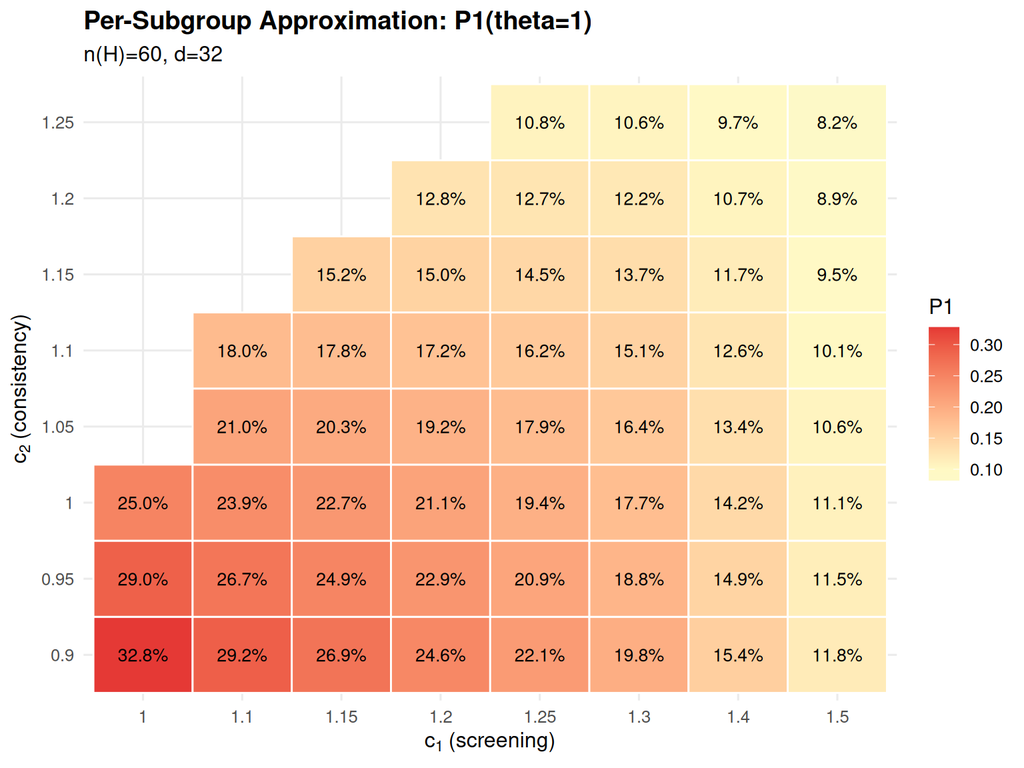

Per-subgroup P1(theta=1) heatmap. This is the single-subgroup probability; the procedure-level FPR is evaluated by simulation below.

```r
ggplot(approx_null, aes(x = factor(c1), y = factor(c2), fill = P1)) +
  geom_tile(colour = "white", linewidth = 0.5) +
  geom_text(aes(label = sprintf("%.1f%%", 100 * P1)),
            size = 3.5, colour = "black") +
  scale_fill_gradient2(
    low = "#E8F5E9", mid = "#FFF9C4", high = "#E53935",
    midpoint = 0.10, name = "P1"
  ) +
  labs(x = expression(c[1] ~ "(screening)"),
       y = expression(c[2] ~ "(consistency)"),
       title = "Per-Subgroup Approximation: P1(theta=1)",
       subtitle = sprintf("n(H)=%d, d=%d", n_H_dgm, d_dgm)) +
  theme_minimal(base_size = 12) +
  theme(plot.title = element_text(face = "bold"))
```

# 5 Part II: Null Simulations

## 5.1 Simulation Parameters

```r
# Build compound parameter objects from setup-chunk scalars
fs_params_base <- list(
  hr.threshold = fs_hr_threshold,
  hr.consistency = fs_hr_consistency,
  pconsistency.threshold = pcons,
  fs.splits = fs_splits,
  n.min = n_min_val,
  d0.min = fs_d0_min, d1.min = fs_d1_min,
  maxk = maxk_val, by.risk = fs_by_risk,
  vi.grf.min = fs_vi_grf_min,
  use_lasso = TRUE, use_grf = TRUE,
  use_twostage = TRUE, twostage_args = list(),
    parallel_args = list(plan="sequential", workers = 1, show_message = FALSE)
)

fs_params_cox <- modifyList(fs_params_base, list(
  outcome.name = "y_sim", event.name = "event_sim",
  treat.name = "treat_sim", id.name = "id"
))


fs_params_irr <- modifyList(fs_params_base, list(
  outcome.name = "event_sim",   # binary event indicator (0/1)
  event.name = "event_sim",
  treat.name = "treat_sim", id.name = "id",
  outcome_type = "binary", effect_measure = "IRR",
  offset.name = "y_sim",        # follow-up time for log(time) offset
  dmin.grf = 0.0
))

sim_config <- list(
  n_sample = n_sample,
  analysis_time = analysis_time,
  seed_base = sim_seed,
  cens_adjust = cens_adjust
)

cat("Simulation config:\n")
```

```
#> Simulation config:
```

```r
cat("  H0 sims:", nsims_null, "\n")
```

```
#>   H0 sims: 20
```

```r
cat("  N:", sim_config$n_sample, "\n")
```

```
#>   N: 700
```

```r
cat("  analysis_time:", sim_config$analysis_time, "months\n")
```

```
#>   analysis_time: 84 months
```

```r
cat("  n.min:", fs_params_base$n.min, "(paper default)\n")
```

```
#>   n.min: 60 (paper default)
```

## 5.2 Cox PH Null Simulations (Paper Defaults)

```r
cat("Running Cox H0 simulations (c1=1.25, c2=1.0)...\n")
```

```
#> Running Cox H0 simulations (c1=1.25, c2=1.0)...
```

```r
t0 <- proc.time()[3]

results_null_cox_raw <- foreach(
  sim = seq_len(nsims_null),
  .errorhandling = "pass",
  .options.future = list(
    packages = c("forestsearch", "survival", "data.table", "future"),
    seed = TRUE)
) %dofuture% {
  future::plan("sequential")
  run_simulation_analysis(
    sim_id = sim, dgm = dgm_null,
    n_sample = sim_config$n_sample,
    analysis_time = sim_config$analysis_time,
    cens_adjust = sim_config$cens_adjust,
    confounders_base = confounders_base,
    cox_formula_adj = cox_formula_adj,
    n_add_noise = 0L,
    run_fs = TRUE, run_fs_grf = FALSE, run_grf = FALSE,
    fs_params = fs_params_cox, verbose = FALSE
  )
}
timings$null_cox <- proc.time()[3] - t0
results_null_cox <- collect_results(results_null_cox_raw, "Cox H0")
if (nrow(results_null_cox) < nsims_null) {
  warning(sprintf(
    "Cox H0: %d of %d tasks silently failed.",
    nsims_null - nrow(results_null_cox), nsims_null
  ))
}
cat("Cox H0:", round(timings$null_cox / 60, 1), "min |",
    nrow(results_null_cox), "/", nsims_null, "rows\n")
```

```
#> Cox H0: 0.1 min | 20 / 20 rows
```

## 5.3 Poisson IRR Null Simulations (Paper Defaults)

```r
cat("Running Poisson IRR H0 simulations (c1=1.25, c2=1.0)...\n")
```

```
#> Running Poisson IRR H0 simulations (c1=1.25, c2=1.0)...
```

```r
t0 <- proc.time()[3]

results_null_irr_raw <- foreach(
  sim = seq_len(nsims_null),
  .errorhandling = "pass",
  .options.future = list(
    packages = c("forestsearch", "survival", "data.table", "future"),
    seed = TRUE)
) %dofuture% {
  future::plan("sequential")
  run_simulation_analysis(
    sim_id = sim, dgm = dgm_null,
    n_sample = sim_config$n_sample,
    analysis_time = sim_config$analysis_time,
    cens_adjust = sim_config$cens_adjust,
    confounders_base = confounders_base,
    cox_formula_adj = cox_formula_adj,
    n_add_noise = 0L,
    run_fs = TRUE, run_fs_grf = FALSE, run_grf = FALSE,
    fs_params = fs_params_irr, verbose = FALSE
  )
}
timings$null_irr <- proc.time()[3] - t0
results_null_irr <- collect_results(results_null_irr_raw, "IRR H0")
if (nrow(results_null_irr) < nsims_null) {
  warning(sprintf(
    "IRR H0: %d of %d tasks silently failed.",
    nsims_null - nrow(results_null_irr), nsims_null
  ))
}
cat("IRR H0:", round(timings$null_irr / 60, 1), "min |",
    nrow(results_null_irr), "/", nsims_null, "rows\n")
```

```
#> IRR H0: 0.2 min | 20 / 20 rows
```

## 5.4 Baseline H0 Comparison: Cox vs Poisson (Paper Defaults)

```r
cox_h0 <- results_null_cox[results_null_cox$analysis == "FS", ]
irr_h0 <- results_null_irr[results_null_irr$analysis == "FS", ]

P1_default <- p_detect_glm(1.0, d_dgm, 1.25, 1.0)

baseline_h0 <- data.frame(
  Metric = c("Simulated FPR", "Per-subgroup P1", "Sim/P1 Ratio",
             "N sims"),
  `Cox PH` = c(
    round(mean(cox_h0$any.H), 4),
    round(P1_default, 4),
    round(mean(cox_h0$any.H) / P1_default, 2),
    nrow(cox_h0)
  ),
  `Poisson IRR` = c(
    round(mean(irr_h0$any.H), 4),
    round(P1_default, 4),
    round(mean(irr_h0$any.H) / P1_default, 2),
    nrow(irr_h0)
  ),
  check.names = FALSE
)

gt(baseline_h0) |>
  tab_header(
    title = md("**H0 Baseline: Cox vs Poisson (c1=1.25, c2=1.0)**"),
    subtitle = sprintf("N=%d, %d sims, HR(ITT)=%.2f",
      sim_config$n_sample, nsims_null,
      dgm_null$hr_causal)
  )
```

H0 comparison at paper defaults (c1=1.25, c2=1.0)

**H0 Baseline: Cox vs Poisson (c1=1.25, c2=1.0)**

N=700, 20 sims, HR(ITT)=0.72

| Metric | Cox PH | Poisson IRR |
| --- | --- | --- |
| Simulated FPR | 0.1000 | 0.2000 |
| Per-subgroup P1 | 0.1944 | 0.1944 |
| Sim/P1 Ratio | 0.5100 | 1.0300 |
| N sims | 20.0000 | 20.0000 |

# 6 Part III: $L_{\text{eff}}$ Calibration

## 6.1 Multi-N Null Simulations

```r
n_sims_cal <- nsims_cal

cat("Running multi-N null calibration simulations...\n")
```

```
#> Running multi-N null calibration simulations...
```

```r
if (n_sims_cal < nsims_null) {
  cat(sprintf("  Note: using nsims_cal = %d (not nsims_null = %d).\n",
              n_sims_cal, nsims_null))
  cat("  For higher precision, increase nsims_cal in the setup chunk.\n")
  cat("  For production-grade calibration, use C2 instead.\n")
}
cat(sprintf("N values: %s | Sims per N: %d\n",
            paste(N_cal_values, collapse = ", "), n_sims_cal))
```

```
#> N values: 300, 500, 700 | Sims per N: 20
```

```r
t0 <- proc.time()[3]

cal_results <- list()
for (N_val in N_cal_values) {
  t_N <- proc.time()[3]

  res_N_raw <- foreach(
    sim = seq_len(n_sims_cal),
    .errorhandling = "pass",
    .options.future = list(
      packages = c("forestsearch", "survival", "data.table", "future"),
      seed = TRUE)
  ) %dofuture% {
    future::plan("sequential")
    run_simulation_analysis(
      sim_id = sim, dgm = dgm_null,
      n_sample = N_val,
      analysis_time = sim_config$analysis_time,
      cens_adjust = sim_config$cens_adjust,
      confounders_base = confounders_base,
      cox_formula_adj = cox_formula_adj,
      n_add_noise = 0L,
      run_fs = TRUE, run_fs_grf = FALSE, run_grf = FALSE,
      fs_params = fs_params_cox, verbose = FALSE
    )
  }

  res_N <- collect_results(res_N_raw, sprintf("cal N=%d", N_val))
  fs_rows <- res_N[res_N$analysis == "FS", ]
  if (nrow(fs_rows) < n_sims_cal) {
    warning(sprintf(
      "Calibration N=%d: %d of %d tasks silently failed.",
      N_val, n_sims_cal - nrow(fs_rows), n_sims_cal
    ))
  }
  fpr_N <- mean(fs_rows$any.H, na.rm = TRUE)

  cal_results[[as.character(N_val)]] <- data.frame(
    N = N_val, sim_fpr = fpr_N, n_sims = nrow(fs_rows)
  )

  cat(sprintf("  N = %4d: FPR = %.3f (%d sims) | %.1f sec\n",
      N_val, fpr_N, nrow(fs_rows), proc.time()[3] - t_N))
}
```

```
#>   N =  300: FPR = 0.050 (20 sims) | 5.3 sec
#>   N =  500: FPR = 0.050 (20 sims) | 4.3 sec
#>   N =  700: FPR = 0.100 (20 sims) | 5.9 sec
```

```r
cal_df <- do.call(rbind, cal_results)
timings$null_cal <- proc.time()[3] - t0
cat(sprintf("Multi-N calibration: %.1f min\n", timings$null_cal / 60))
```

```
#> Multi-N calibration: 0.3 min
```

## 6.2 Implied $L_{\text{eff}}$ from Simulation

For each $N$, solve for the implied $L_{\text{eff}}$:

$$L_{\text{eff}} =
\frac{\log(1 - \text{FPR}_{\text{sim}})}
{\log(1 - P_1)}$$

```r
cal_df$n_H <- n_min_val
cal_df$d_eff <- round(d_eff_survival(cal_df$n_H, prop_cens))
cal_df$P1 <- sapply(cal_df$d_eff, function(d) {
  p_detect_glm(1.0, d, 1.25, 1.0)
})
cal_df$L_eff <- log(1 - cal_df$sim_fpr) / log(1 - cal_df$P1)

cat("=== Implied L_eff ===\n")
```

```
#> === Implied L_eff ===
```

```r
print(cal_df[, c("N", "n_H", "d_eff", "P1", "sim_fpr", "L_eff")])
```

```
#>       N n_H d_eff       P1 sim_fpr     L_eff
#> 300 300  60    32 0.194358    0.05 0.2373417
#> 500 500  60    32 0.194358    0.05 0.2373417
#> 700 700  60    32 0.194358    0.10 0.4875188
```

## 6.3 Fit $L_{\text{eff}}$ Power Law

```
#> L_eff Calibration
#>   Model: L_eff = 0.060 * (N / 60)^0.780
#>   R-squared: 0.642
#>   Calibrated at N = 300, 500, 700
#>
#>   Implied L_eff:
#>     N =  300: L_eff = 0.24 (fitted: 0.21)
#>     N =  500: L_eff = 0.24 (fitted: 0.32)
#>     N =  700: L_eff = 0.49 (fitted: 0.41)
```

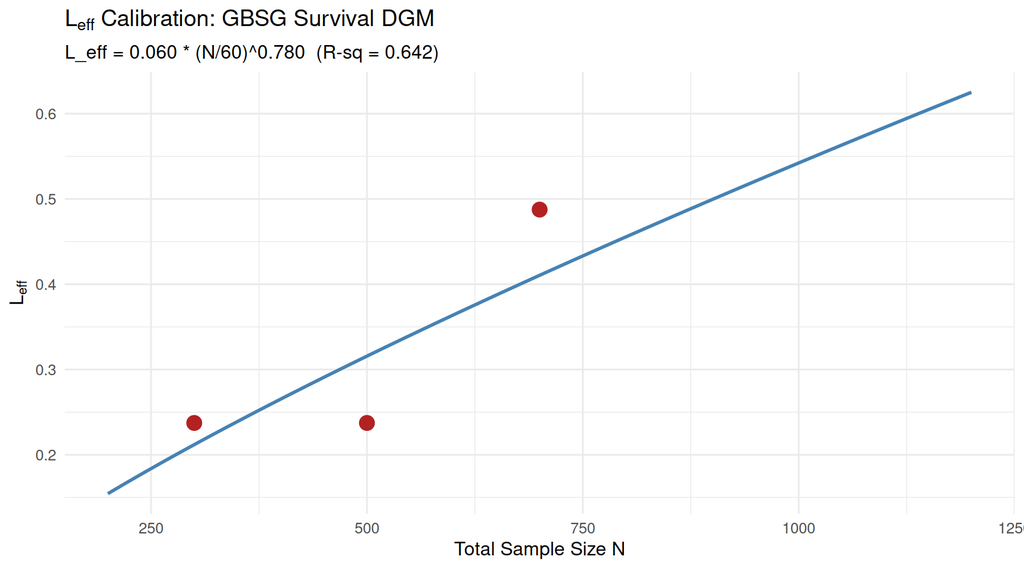

Implied L_eff with power-law fit for the GBSG survival DGM.

```r
# Fit power law
cal_valid <- cal_df[cal_df$sim_fpr > 0 & cal_df$P1 > 0 &
                     is.finite(cal_df$L_eff), ]

if (nrow(cal_valid) >= 2) {
  leff_cal <- calibrate_L_eff(
    N = cal_valid$N, P1 = cal_valid$P1,
    sim_fpr = cal_valid$sim_fpr, n_min = n_min_val
  )
  print(leff_cal)

  C_fit <- leff_cal$C
  alpha_fit <- leff_cal$alpha

  N_pred <- seq(200, 1200, by = 5)
  pred_curve <- data.frame(
    N = N_pred, L_eff = C_fit * (N_pred / n_min_val)^alpha_fit
  )

  ggplot() +
    geom_point(data = cal_valid, aes(x = N, y = L_eff),
               size = 4, colour = "firebrick") +
    geom_line(data = pred_curve, aes(x = N, y = L_eff),
              colour = "steelblue", linewidth = 1) +
    labs(x = "Total Sample Size N",
         y = expression(L[eff]),
         title = expression(L[eff] * " Calibration: GBSG Survival DGM"),
         subtitle = sprintf("L_eff = %.3f * (N/%d)^%.3f  (R-sq = %.3f)",
                             C_fit, n_min_val, alpha_fit,
                             leff_cal$r_squared)) +
    theme_minimal(base_size = 12) +
    theme(plot.title = element_text(face = "bold"))
} else {
  cat("Insufficient calibration points. Using L_eff = 1.\n")
  C_fit <- 1; alpha_fit <- 0
}
```

```r
cat(sprintf("\nFitted model: L_eff = %.3f * (N/%d)^%.3f\n",
            C_fit, n_min_val, alpha_fit))
```

```
#>
#> Fitted model: L_eff = 0.060 * (N/60)^0.780
```

```r
cat(sprintf("  N = 300:  L_eff = %.2f\n", C_fit * (300/n_min_val)^alpha_fit))
```

```
#>   N = 300:  L_eff = 0.21
```

```r
cat(sprintf("  N = 500:  L_eff = %.2f\n", C_fit * (500/n_min_val)^alpha_fit))
```

```
#>   N = 500:  L_eff = 0.32
```

```r
cat(sprintf("  N = 700:  L_eff = %.2f\n", C_fit * (700/n_min_val)^alpha_fit))
```

```
#>   N = 700:  L_eff = 0.41
```

## 6.4 Save Calibration

```r
# Save calibration to .rds for downstream documents (S2)
save_leff_calibration(
  C = C_fit,
  alpha = alpha_fit,
  n_min = n_min_val,
  outcome_type = "survival",
  cal_data = cal_df,
  dgm_description = paste(
    "GBSG survival DGM,", length(confounders_base), "confounders",
    paste0("(", paste(confounders_base, collapse = ", "), "),"),
    sprintf("prop_cens=%.2f, p_harm=%.2f", prop_cens, p_harm)),
  n_sims_per_N = n_sims_cal,
  output_dir = output_dir,
  extra = list(
    # ForestSearch config (S2 should match these)
    confounders_base = confounders_base,
    prop_cens        = prop_cens,
    p_harm           = p_harm,
    hr_h1            = hr_h1,
    pcons            = pcons,
    fs_splits        = fs_splits,
    maxk_val         = maxk_val,
    n_min_val        = n_min_val,
    analysis_time    = analysis_time,
    cens_adjust      = cens_adjust,
    fpr_target       = fpr_target,
    N_cal_values     = N_cal_values,
    # Grid range validated for L_eff threshold-independence
    c1_range = range(c1_grid),
    c2_range = range(c2_grid)
  )
)
```

```
#> L_eff calibration saved: _data/calibration_survival_leff.rds
```

```
#>   outcome: survival | C = 0.0604 | alpha = 0.7803 | n_min = 60
```

```
#>   Size: 0.8 KB
```

**ImportantShared `.rds` With C2**

Both this document (C3) and `calibration_survival_fourway.qmd` (C2) save to `calibration_survival_leff.rds`. **C2 is the primary source** (up to 20K replicates per N). C3 uses fewer replicates and is designed as a faster grid sweep. If both are rendered, the last-rendered file wins. To avoid overwriting C2’s calibration, set `recalibrate = FALSE` in this document or render C2 after C3.

## 6.5 Corrected Baseline

```r
L_eff_main <- C_fit * (n_sample / n_min_val)^alpha_fit
P1_cox <- p_detect_glm(1.0, d_dgm, 1.25, 1.0)
fpr_corr <- 1 - (1 - P1_cox)^L_eff_main

cat(sprintf("=== Corrected Baseline (N=%d, c1=1.25, c2=1.0) ===\n",
            n_sample))
```

```
#> === Corrected Baseline (N=700, c1=1.25, c2=1.0) ===
```

```r
cat(sprintf("  L_eff:         %.2f\n", L_eff_main))
```

```
#>   L_eff:         0.41
```

```r
cat(sprintf("  P1 (uncorr):   %.3f\n", P1_cox))
```

```
#>   P1 (uncorr):   0.194
```

```r
cat(sprintf("  FPR (corr):    %.3f\n", fpr_corr))
```

```
#>   FPR (corr):    0.085
```

```r
cat(sprintf("  Sim FPR (Cox): %.3f\n", mean(cox_h0$any.H)))
```

```
#>   Sim FPR (Cox): 0.100
```

```r
cat(sprintf("  Sim FPR (IRR): %.3f\n", mean(irr_h0$any.H)))
```

```
#>   Sim FPR (IRR): 0.200
```

```r
cat(sprintf("  Sim/Corr:      %.2f\n",
            mean(cox_h0$any.H) / max(fpr_corr, 0.001)))
```

```
#>   Sim/Corr:      1.18
```

# 7 Part IV: Null Threshold Grid

Systematic evaluation of $(c_1, c_2)$ pairs under $H_0$ at $N = 700$ to identify the region where FPR $\le$ 12%.

Grid defined in the setup chunk: `c1_grid` and `c2_grid`.

## 7.1 Grid Design

```r
grid_pairs <- expand.grid(c1 = c1_grid, c2 = c2_grid,
                           stringsAsFactors = FALSE)
grid_pairs <- grid_pairs[grid_pairs$c2 <= grid_pairs$c1, ]

N_grid     <- n_sample

cat(sprintf("Null grid: %d (c1,c2) pairs x %d sims = %d tasks at N = %d\n",
    nrow(grid_pairs), nsims_grid,
    nrow(grid_pairs) * nsims_grid, N_grid))
```

```
#> Null grid: 53 (c1,c2) pairs x 20 sims = 1060 tasks at N = 700
```

```r
if (nsims_grid < nsims_null) {
  cat(sprintf("  Note: using nsims_grid = %d (not nsims_null = %d).\n",
              nsims_grid, nsims_null))
  cat("  To increase grid precision, raise nsims_grid in the setup chunk.\n")
}
cat(sprintf("(c1 range: %.2f--%.2f, c2 range: %.2f--%.2f)\n",
    min(c1_grid), max(c1_grid), min(c2_grid), max(c2_grid)))
```

```
#> (c1 range: 1.00--1.50, c2 range: 0.90--1.25)
```

## 7.2 Run Grid Simulations

```r
t0 <- proc.time()[3]

grid_tasks <- do.call(rbind, lapply(seq_len(nrow(grid_pairs)), function(g) {
  data.frame(
    grid_id = g, sim = seq_len(nsims_grid),
    c1 = grid_pairs$c1[g], c2 = grid_pairs$c2[g],
    stringsAsFactors = FALSE
  )
}))

cat(sprintf("Running %d null grid tasks...\n", nrow(grid_tasks)))
```

```
#> Running 1060 null grid tasks...
```

```r
grid_results_raw <- foreach(
  i = seq_len(nrow(grid_tasks)),
  .errorhandling = "pass",
  .options.future = list(
    packages = c("forestsearch", "survival", "data.table", "future"),
    seed = TRUE)
) %dofuture% {
  future::plan("sequential")
  sim_id <- grid_tasks$sim[i]
  c1_val <- grid_tasks$c1[i]
  c2_val <- grid_tasks$c2[i]

  fs_params_grid <- modifyList(fs_params_cox, list(
    hr.threshold = c1_val,
    hr.consistency = c2_val
  ))

  res <- run_simulation_analysis(
    sim_id = sim_id, dgm = dgm_null,
    n_sample = N_grid,
    analysis_time = sim_config$analysis_time,
    cens_adjust = sim_config$cens_adjust,
    confounders_base = confounders_base,
    cox_formula_adj = cox_formula_adj,
    n_add_noise = 0L,
    run_fs = TRUE, run_fs_grf = FALSE, run_grf = FALSE,
    fs_params = fs_params_grid, verbose = FALSE
  )

  fs_row <- res[res$analysis == "FS", ]
  data.frame(
    sim = sim_id, c1 = c1_val, c2 = c2_val,
    any_H = if (nrow(fs_row) > 0) fs_row$any.H[1] else 0L,
    stringsAsFactors = FALSE
  )
}

timings$null_grid <- proc.time()[3] - t0
grid_results <- collect_results(grid_results_raw, "null grid")
n_expected_grid <- nrow(grid_tasks)
n_failed_grid   <- attr(grid_results, "n_failed")
cat(sprintf("Null grid: %.1f min | %d/%d results (%d failed)\n",
    timings$null_grid / 60, nrow(grid_results), n_expected_grid, n_failed_grid))
```

```
#> Null grid: 1.7 min | 1060/1060 results (0 failed)
```

# 8 Part V: Results

## 8.1 FPR Table

```r
grid_dt <- data.table(grid_results)
grid_fpr <- grid_dt[, .(
  FPR = mean(any_H, na.rm = TRUE),
  n_found = sum(any_H, na.rm = TRUE),
  n_sims = .N
), by = .(c1, c2)]

# Add approximations
grid_fpr[, P1 := mapply(function(c1v, c2v) {
  p_detect_glm(1.0, d_dgm, c1v, c2v)
}, c1, c2)]

# L_eff corrected
L_eff_N <- C_fit * (N_grid / n_min_val)^alpha_fit
grid_fpr[, FPR_corr := 1 - (1 - P1)^L_eff_N]
grid_fpr[, Sim_over_P1   := round(FPR / pmax(P1, 0.001), 2)]
grid_fpr[, Sim_over_Corr := round(FPR / pmax(FPR_corr, 0.001), 2)]

gt(grid_fpr[, .(c1, c2,
                `Sim FPR` = round(FPR, 3),
                `Found/Total` = sprintf("%d/%d", n_found, n_sims),
                `P1 (uncorr)` = round(P1, 3),
                `FPR (corr)` = round(FPR_corr, 3),
                `Sim/P1` = Sim_over_P1,
                `Sim/Corr` = Sim_over_Corr)]) |>
  tab_header(
    title = md("**Simulated FPR Under H0 by Threshold Pair**"),
    subtitle = sprintf("N=%d, %d sims/pair, n.min=%d, pcons=%.2f, L_eff=%.2f",
                        N_grid, nsims_grid, n_min_val, pcons, L_eff_N)
  ) |>
  tab_style(style = cell_fill(color = "#E8F5E9"),
    locations = cells_body(columns = `Sim FPR`,
      rows = `Sim FPR` <= 0.10)) |>
  tab_style(style = cell_fill(color = "#FFF9C4"),
    locations = cells_body(columns = `Sim FPR`,
      rows = `Sim FPR` > 0.10 & `Sim FPR` <= fpr_target)) |>
  tab_style(style = cell_fill(color = "#FFEBEE"),
    locations = cells_body(columns = `Sim FPR`,
      rows = `Sim FPR` > fpr_target)) |>
  tab_source_note(sprintf(
    "Green: FPR <= 10%%. Yellow: 10-%.0f%%. Red: > %.0f%%.",
    100 * fpr_target, 100 * fpr_target))
```

Simulated FPR under H0 by (c1, c2). Green: FPR <= 10%. Yellow: 10-12%. Red: > 12%.

**Simulated FPR Under H0 by Threshold Pair**

N=700, 20 sims/pair, n.min=60, pcons=0.90, L_eff=0.41

| c1 | c2 | Sim FPR | Found/Total | P1 (uncorr) | FPR (corr) | Sim/P1 | Sim/Corr |
| --- | --- | --- | --- | --- | --- | --- | --- |
| 1.00 | 0.90 | 0.25 | 5/20 | 0.328 | 0.150 | 0.76 | 1.66 |
| 1.10 | 0.90 | 0.25 | 5/20 | 0.292 | 0.132 | 0.86 | 1.89 |
| 1.15 | 0.90 | 0.25 | 5/20 | 0.269 | 0.121 | 0.93 | 2.07 |
| 1.20 | 0.90 | 0.25 | 5/20 | 0.246 | 0.109 | 1.02 | 2.29 |
| 1.25 | 0.90 | 0.25 | 5/20 | 0.222 | 0.098 | 1.13 | 2.56 |
| 1.30 | 0.90 | 0.25 | 5/20 | 0.198 | 0.087 | 1.26 | 2.89 |
| 1.40 | 0.90 | 0.20 | 4/20 | 0.154 | 0.067 | 1.30 | 3.01 |
| 1.50 | 0.90 | 0.10 | 2/20 | 0.118 | 0.050 | 0.85 | 2.00 |
| 1.00 | 0.95 | 0.15 | 3/20 | 0.290 | 0.131 | 0.52 | 1.14 |
| 1.10 | 0.95 | 0.15 | 3/20 | 0.267 | 0.120 | 0.56 | 1.25 |
| 1.15 | 0.95 | 0.15 | 3/20 | 0.249 | 0.111 | 0.60 | 1.35 |
| 1.20 | 0.95 | 0.15 | 3/20 | 0.230 | 0.102 | 0.65 | 1.48 |
| 1.25 | 0.95 | 0.15 | 3/20 | 0.209 | 0.092 | 0.72 | 1.64 |
| 1.30 | 0.95 | 0.15 | 3/20 | 0.188 | 0.082 | 0.80 | 1.83 |
| 1.40 | 0.95 | 0.15 | 3/20 | 0.149 | 0.064 | 1.01 | 2.34 |
| 1.50 | 0.95 | 0.10 | 2/20 | 0.114 | 0.049 | 0.87 | 2.05 |
| 1.00 | 1.00 | 0.10 | 2/20 | 0.250 | 0.111 | 0.40 | 0.90 |
| 1.10 | 1.00 | 0.10 | 2/20 | 0.239 | 0.106 | 0.42 | 0.94 |
| 1.15 | 1.00 | 0.10 | 2/20 | 0.227 | 0.100 | 0.44 | 1.00 |
| 1.20 | 1.00 | 0.10 | 2/20 | 0.211 | 0.093 | 0.47 | 1.08 |
| 1.25 | 1.00 | 0.10 | 2/20 | 0.194 | 0.085 | 0.51 | 1.18 |
| 1.30 | 1.00 | 0.10 | 2/20 | 0.177 | 0.077 | 0.57 | 1.30 |
| 1.40 | 1.00 | 0.10 | 2/20 | 0.142 | 0.061 | 0.70 | 1.64 |
| 1.50 | 1.00 | 0.10 | 2/20 | 0.111 | 0.047 | 0.90 | 2.13 |
| 1.10 | 1.05 | 0.05 | 1/20 | 0.210 | 0.092 | 0.24 | 0.54 |
| 1.15 | 1.05 | 0.05 | 1/20 | 0.203 | 0.089 | 0.25 | 0.56 |
| 1.20 | 1.05 | 0.05 | 1/20 | 0.192 | 0.084 | 0.26 | 0.60 |
| 1.25 | 1.05 | 0.05 | 1/20 | 0.179 | 0.078 | 0.28 | 0.64 |
| 1.30 | 1.05 | 0.05 | 1/20 | 0.165 | 0.071 | 0.30 | 0.70 |
| 1.40 | 1.05 | 0.05 | 1/20 | 0.134 | 0.057 | 0.37 | 0.87 |
| 1.50 | 1.05 | 0.05 | 1/20 | 0.106 | 0.045 | 0.47 | 1.11 |
| 1.10 | 1.10 | 0.00 | 0/20 | 0.180 | 0.078 | 0.00 | 0.00 |
| 1.15 | 1.10 | 0.00 | 0/20 | 0.178 | 0.077 | 0.00 | 0.00 |
| 1.20 | 1.10 | 0.00 | 0/20 | 0.172 | 0.074 | 0.00 | 0.00 |
| 1.25 | 1.10 | 0.00 | 0/20 | 0.162 | 0.070 | 0.00 | 0.00 |
| 1.30 | 1.10 | 0.00 | 0/20 | 0.151 | 0.065 | 0.00 | 0.00 |
| 1.40 | 1.10 | 0.00 | 0/20 | 0.126 | 0.054 | 0.00 | 0.00 |
| 1.50 | 1.10 | 0.00 | 0/20 | 0.101 | 0.043 | 0.00 | 0.00 |
| 1.15 | 1.15 | 0.00 | 0/20 | 0.152 | 0.066 | 0.00 | 0.00 |
| 1.20 | 1.15 | 0.00 | 0/20 | 0.150 | 0.065 | 0.00 | 0.00 |
| 1.25 | 1.15 | 0.00 | 0/20 | 0.145 | 0.062 | 0.00 | 0.00 |
| 1.30 | 1.15 | 0.00 | 0/20 | 0.137 | 0.059 | 0.00 | 0.00 |
| 1.40 | 1.15 | 0.00 | 0/20 | 0.117 | 0.050 | 0.00 | 0.00 |
| 1.50 | 1.15 | 0.00 | 0/20 | 0.095 | 0.040 | 0.00 | 0.00 |
| 1.20 | 1.20 | 0.00 | 0/20 | 0.129 | 0.055 | 0.00 | 0.00 |
| 1.25 | 1.20 | 0.00 | 0/20 | 0.127 | 0.054 | 0.00 | 0.00 |
| 1.30 | 1.20 | 0.00 | 0/20 | 0.122 | 0.052 | 0.00 | 0.00 |
| 1.40 | 1.20 | 0.00 | 0/20 | 0.107 | 0.045 | 0.00 | 0.00 |
| 1.50 | 1.20 | 0.00 | 0/20 | 0.089 | 0.038 | 0.00 | 0.00 |
| 1.25 | 1.25 | 0.00 | 0/20 | 0.108 | 0.046 | 0.00 | 0.00 |
| 1.30 | 1.25 | 0.00 | 0/20 | 0.106 | 0.045 | 0.00 | 0.00 |
| 1.40 | 1.25 | 0.00 | 0/20 | 0.096 | 0.041 | 0.00 | 0.00 |
| 1.50 | 1.25 | 0.00 | 0/20 | 0.082 | 0.035 | 0.00 | 0.00 |

Green: FPR <= 10%. Yellow: 10-12%. Red: > 12%.

## 8.2 $L_{\text{eff}}$ Consistency Across Threshold Pairs

If $L_{\text{eff}}$ is truly a property of the candidate-generation process (confounders, GRF, LASSO, maxk, n.min) and not the threshold pair, the implied $L_{\text{eff}}$ should be approximately constant across $(c_1, c_2)$ at the same $N$.

```r
# Compute implied L_eff for each grid pair
grid_fpr[, implied_L_eff := ifelse(
  P1 > 0 & FPR > 0 & FPR < 1,
  log(1 - FPR) / log(1 - P1),
  NA_real_
)]

leff_summary <- grid_fpr[!is.na(implied_L_eff), .(
  `Median` = round(median(implied_L_eff), 2),
  `Min`    = round(min(implied_L_eff), 2),
  `Max`    = round(max(implied_L_eff), 2),
  `SD`     = round(sd(implied_L_eff), 3),
  `CV`     = sprintf("%.0f%%", 100 * sd(implied_L_eff) /
                      median(implied_L_eff)),
  `n_pairs` = .N
)]

cat(sprintf(
  "Calibrated L_eff at N=%d: %.2f\n", N_grid, L_eff_N))
```

```
#> Calibrated L_eff at N=700: 0.41
```

```r
cat(sprintf(
  "Implied L_eff across %d threshold pairs: median=%.2f, range=[%.2f, %.2f]\n",
  leff_summary$n_pairs, leff_summary$Median,
  leff_summary$Min, leff_summary$Max))
```

```
#> Implied L_eff across 31 threshold pairs: median=0.57, range=[0.22, 1.33]
```

```r
gt(grid_fpr[!is.na(implied_L_eff),
  .(c1, c2,
    `Sim FPR` = sprintf("%.1f%%", 100 * FPR),
    `P1` = sprintf("%.4f", P1),
    `Implied L_eff` = round(implied_L_eff, 2),
    `Calibrated L_eff` = round(L_eff_N, 2),
    `Ratio` = round(implied_L_eff / L_eff_N, 2)
  )]) |>
  tab_header(
    title = md("**L_eff Consistency Diagnostic**"),
    subtitle = sprintf("N=%d | Calibrated: L_eff = %.3f * (N/%d)^%.3f = %.2f",
                        N_grid, C_fit, n_min_val, alpha_fit, L_eff_N)
  ) |>
  tab_style(style = cell_fill(color = "#E8F5E9"),
    locations = cells_body(columns = Ratio,
      rows = Ratio >= 0.7 & Ratio <= 1.3)) |>
  tab_style(style = cell_fill(color = "#FFEBEE"),
    locations = cells_body(columns = Ratio,
      rows = Ratio < 0.7 | Ratio > 1.3)) |>
  tab_source_note(paste(
    "Ratio = Implied / Calibrated.",
    "Green: within +/-30%.  Red: outside +/-30%.",
    "Constant ratio supports threshold-independence."))
```

Implied L_eff at each (c1, c2) pair. If L_eff is threshold-independent, values should cluster near the calibrated value.

**L_eff Consistency Diagnostic**

N=700 | Calibrated: L_eff = 0.060 * (N/60)^0.780 = 0.41

| c1 | c2 | Sim FPR | P1 | Implied L_eff | Calibrated L_eff | Ratio |
| --- | --- | --- | --- | --- | --- | --- |
| 1.00 | 0.90 | 25.0% | 0.3278 | 0.72 | 0.41 | 1.76 |
| 1.10 | 0.90 | 25.0% | 0.2919 | 0.83 | 0.41 | 2.03 |
| 1.15 | 0.90 | 25.0% | 0.2694 | 0.92 | 0.41 | 2.23 |
| 1.20 | 0.90 | 25.0% | 0.2455 | 1.02 | 0.41 | 2.49 |
| 1.25 | 0.90 | 25.0% | 0.2215 | 1.15 | 0.41 | 2.80 |
| 1.30 | 0.90 | 25.0% | 0.1980 | 1.30 | 0.41 | 3.18 |
| 1.40 | 0.90 | 20.0% | 0.1544 | 1.33 | 0.41 | 3.24 |
| 1.50 | 0.90 | 10.0% | 0.1177 | 0.84 | 0.41 | 2.05 |
| 1.00 | 0.95 | 15.0% | 0.2903 | 0.47 | 0.41 | 1.15 |
| 1.10 | 0.95 | 15.0% | 0.2668 | 0.52 | 0.41 | 1.28 |
| 1.15 | 0.95 | 15.0% | 0.2492 | 0.57 | 0.41 | 1.38 |
| 1.20 | 0.95 | 15.0% | 0.2295 | 0.62 | 0.41 | 1.52 |
| 1.25 | 0.95 | 15.0% | 0.2089 | 0.69 | 0.41 | 1.69 |
| 1.30 | 0.95 | 15.0% | 0.1884 | 0.78 | 0.41 | 1.90 |
| 1.40 | 0.95 | 15.0% | 0.1487 | 1.01 | 0.41 | 2.46 |
| 1.50 | 0.95 | 10.0% | 0.1145 | 0.87 | 0.41 | 2.11 |
| 1.00 | 1.00 | 10.0% | 0.2502 | 0.37 | 0.41 | 0.89 |
| 1.10 | 1.00 | 10.0% | 0.2390 | 0.39 | 0.41 | 0.94 |
| 1.15 | 1.00 | 10.0% | 0.2266 | 0.41 | 0.41 | 1.00 |
| 1.20 | 1.00 | 10.0% | 0.2113 | 0.44 | 0.41 | 1.08 |
| 1.25 | 1.00 | 10.0% | 0.1944 | 0.49 | 0.41 | 1.19 |
| 1.30 | 1.00 | 10.0% | 0.1770 | 0.54 | 0.41 | 1.32 |
| 1.40 | 1.00 | 10.0% | 0.1419 | 0.69 | 0.41 | 1.68 |
| 1.50 | 1.00 | 10.0% | 0.1106 | 0.90 | 0.41 | 2.19 |
| 1.10 | 1.05 | 5.0% | 0.2104 | 0.22 | 0.41 | 0.53 |
| 1.15 | 1.05 | 5.0% | 0.2030 | 0.23 | 0.41 | 0.55 |
| 1.20 | 1.05 | 5.0% | 0.1920 | 0.24 | 0.41 | 0.59 |
| 1.25 | 1.05 | 5.0% | 0.1788 | 0.26 | 0.41 | 0.63 |
| 1.30 | 1.05 | 5.0% | 0.1645 | 0.29 | 0.41 | 0.70 |
| 1.40 | 1.05 | 5.0% | 0.1342 | 0.36 | 0.41 | 0.87 |
| 1.50 | 1.05 | 5.0% | 0.1061 | 0.46 | 0.41 | 1.11 |

Ratio = Implied / Calibrated. Green: within +/-30%. Red: outside +/-30%. Constant ratio supports threshold-independence.

## 8.3 FPR Heatmap

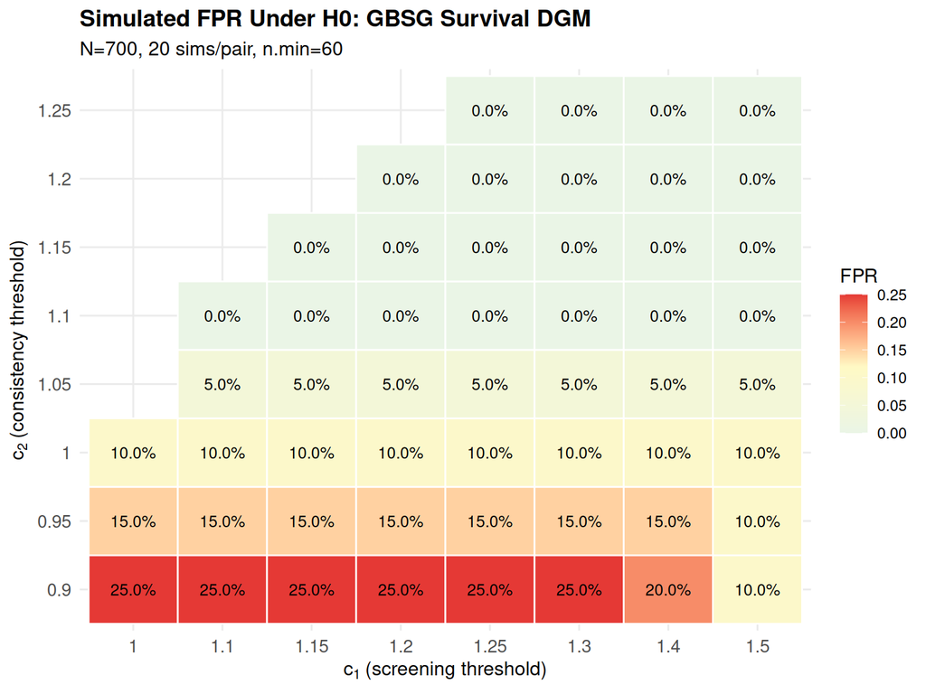

Simulated FPR heatmap by (c1, c2). Values <= 12% are in the acceptable region.

```r
ggplot(grid_fpr, aes(x = factor(c1), y = factor(c2), fill = FPR)) +
  geom_tile(colour = "white", linewidth = 0.5) +
  geom_text(aes(label = sprintf("%.1f%%", 100 * FPR)),
            size = 3.5, colour = "black") +
  scale_fill_gradient2(
    low = "#E8F5E9", mid = "#FFF9C4", high = "#E53935",
    midpoint = fpr_target,
    limits = c(0, max(grid_fpr$FPR, 0.20)),
    name = "FPR"
  ) +
  labs(x = expression(c[1] ~ "(screening threshold)"),
       y = expression(c[2] ~ "(consistency threshold)"),
       title = "Simulated FPR Under H0: GBSG Survival DGM",
       subtitle = sprintf("N=%d, %d sims/pair, n.min=%d",
                           N_grid, nsims_grid, n_min_val)) +
  theme_minimal(base_size = 12) +
  theme(plot.title = element_text(face = "bold"),
        axis.text = element_text(size = 11))
```

## 8.4 FPR Sensitivity to $c_2$ (Fixing $c_1$)

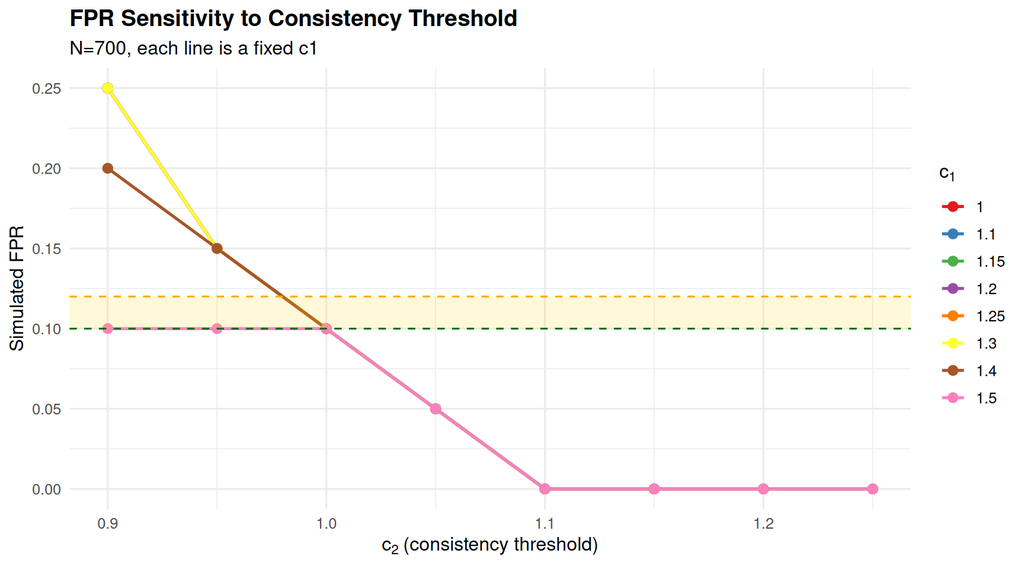

FPR vs c2 for each fixed c1. The target band is highlighted.

```r
ggplot(grid_fpr, aes(x = c2, y = FPR,
                      colour = factor(c1), group = factor(c1))) +
  geom_line(linewidth = 0.9) +
  geom_point(size = 2.5) +
  geom_hline(yintercept = 0.10, linetype = "dashed", colour = "darkgreen") +
  geom_hline(yintercept = fpr_target, linetype = "dashed", colour = "orange") +
  annotate("rect", xmin = -Inf, xmax = Inf,
           ymin = 0.10, ymax = fpr_target,
           alpha = 0.15, fill = "gold") +
  scale_colour_brewer(palette = "Set1") +
  labs(x = expression(c[2] ~ "(consistency threshold)"),
       y = "Simulated FPR",
       title = "FPR Sensitivity to Consistency Threshold",
       subtitle = sprintf("N=%d, each line is a fixed c1", N_grid),
       colour = expression(c[1])) +
  theme_minimal(base_size = 12) +
  theme(legend.position = "right",
        plot.title = element_text(face = "bold"))
```

## 8.5 FPR Sensitivity to $c_1$ (Fixing $c_2$)

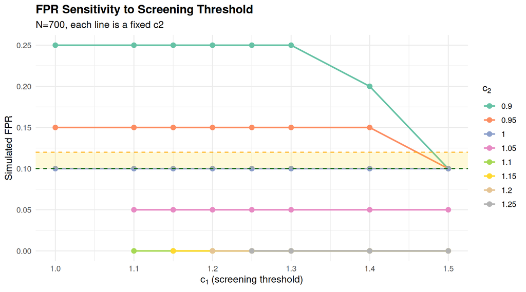

FPR vs c1 for each fixed c2. Shows the screening threshold’s independent effect.

```r
ggplot(grid_fpr, aes(x = c1, y = FPR,
                      colour = factor(c2), group = factor(c2))) +
  geom_line(linewidth = 0.9) +
  geom_point(size = 2.5) +
  geom_hline(yintercept = 0.10, linetype = "dashed", colour = "darkgreen") +
  geom_hline(yintercept = fpr_target, linetype = "dashed", colour = "orange") +
  annotate("rect", xmin = -Inf, xmax = Inf,
           ymin = 0.10, ymax = fpr_target,
           alpha = 0.15, fill = "gold") +
  scale_colour_brewer(palette = "Set2") +
  labs(x = expression(c[1] ~ "(screening threshold)"),
       y = "Simulated FPR",
       title = "FPR Sensitivity to Screening Threshold",
       subtitle = sprintf("N=%d, each line is a fixed c2", N_grid),
       colour = expression(c[2])) +
  theme_minimal(base_size = 12) +
  theme(legend.position = "right",
        plot.title = element_text(face = "bold"))
```

## 8.6 Approximation Accuracy Across the Grid

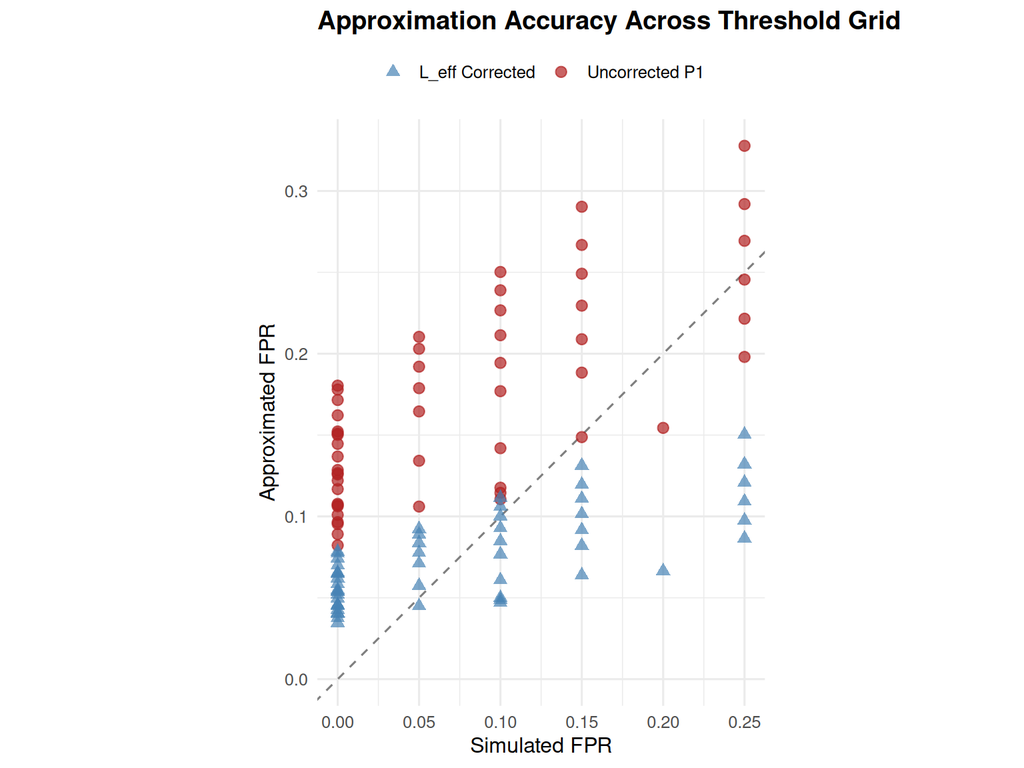

Approximation vs simulation across the (c1,c2) grid. Corrected points (triangles) should cluster near the diagonal.

```r
ggplot(grid_fpr, aes(x = FPR)) +
  geom_abline(slope = 1, intercept = 0, linetype = "dashed",
              colour = "grey50") +
  geom_point(aes(y = P1, colour = "Uncorrected P1"),
             size = 2.5, alpha = 0.7) +
  geom_point(aes(y = FPR_corr, colour = "L_eff Corrected"),
             size = 2.5, alpha = 0.7, shape = 17) +
  scale_colour_manual(values = c("Uncorrected P1" = "firebrick",
                                  "L_eff Corrected" = "steelblue")) +
  coord_equal(xlim = c(0, max(grid_fpr$FPR, 0.25)),
              ylim = c(0, max(grid_fpr$P1, 0.25))) +
  labs(x = "Simulated FPR", y = "Approximated FPR",
       title = "Approximation Accuracy Across Threshold Grid",
       colour = NULL) +
  theme_minimal(base_size = 12) +
  theme(legend.position = "top",
        plot.title = element_text(face = "bold"))
```

## 8.7 Acceptable Region (FPR $\le$ 12%)

```r
acceptable_grid <- grid_fpr[FPR <= fpr_target]
setorder(acceptable_grid, FPR)

if (nrow(acceptable_grid) > 0) {
  gt(acceptable_grid[, .(c1, c2,
    `Sim FPR` = sprintf("%.1f%%", 100 * FPR),
    `P1 (uncorr)` = sprintf("%.1f%%", 100 * P1),
    `FPR (corr)` = sprintf("%.1f%%", 100 * FPR_corr))]) |>
    tab_header(
      title = md(sprintf(
        "**Acceptable Threshold Configurations (FPR <= %.0f%%)**",
        100 * fpr_target)),
      subtitle = sprintf("N=%d, GBSG survival DGM, n.min=%d",
                          N_grid, n_min_val)
    ) |>
    tab_source_note("Paper defaults: c1=1.25, c2=1.0")
} else {
  cat(sprintf("No configurations achieved FPR <= %.0f%% in this grid.\n",
              100 * fpr_target))
}
```

Threshold pairs with simulated FPR <= 12%

**Acceptable Threshold Configurations (FPR <= 12%)**

N=700, GBSG survival DGM, n.min=60

| c1 | c2 | Sim FPR | P1 (uncorr) | FPR (corr) |
| --- | --- | --- | --- | --- |
| 1.10 | 1.10 | 0.0% | 18.0% | 7.8% |
| 1.15 | 1.10 | 0.0% | 17.8% | 7.7% |
| 1.20 | 1.10 | 0.0% | 17.2% | 7.4% |
| 1.25 | 1.10 | 0.0% | 16.2% | 7.0% |
| 1.30 | 1.10 | 0.0% | 15.1% | 6.5% |
| 1.40 | 1.10 | 0.0% | 12.6% | 5.4% |
| 1.50 | 1.10 | 0.0% | 10.1% | 4.3% |
| 1.15 | 1.15 | 0.0% | 15.2% | 6.6% |
| 1.20 | 1.15 | 0.0% | 15.0% | 6.5% |
| 1.25 | 1.15 | 0.0% | 14.5% | 6.2% |
| 1.30 | 1.15 | 0.0% | 13.7% | 5.9% |
| 1.40 | 1.15 | 0.0% | 11.7% | 5.0% |
| 1.50 | 1.15 | 0.0% | 9.5% | 4.0% |
| 1.20 | 1.20 | 0.0% | 12.9% | 5.5% |
| 1.25 | 1.20 | 0.0% | 12.7% | 5.4% |
| 1.30 | 1.20 | 0.0% | 12.2% | 5.2% |
| 1.40 | 1.20 | 0.0% | 10.7% | 4.5% |
| 1.50 | 1.20 | 0.0% | 8.9% | 3.8% |
| 1.25 | 1.25 | 0.0% | 10.8% | 4.6% |
| 1.30 | 1.25 | 0.0% | 10.6% | 4.5% |
| 1.40 | 1.25 | 0.0% | 9.6% | 4.1% |
| 1.50 | 1.25 | 0.0% | 8.2% | 3.5% |
| 1.10 | 1.05 | 5.0% | 21.0% | 9.2% |
| 1.15 | 1.05 | 5.0% | 20.3% | 8.9% |
| 1.20 | 1.05 | 5.0% | 19.2% | 8.4% |
| 1.25 | 1.05 | 5.0% | 17.9% | 7.8% |
| 1.30 | 1.05 | 5.0% | 16.5% | 7.1% |
| 1.40 | 1.05 | 5.0% | 13.4% | 5.7% |
| 1.50 | 1.05 | 5.0% | 10.6% | 4.5% |
| 1.50 | 0.90 | 10.0% | 11.8% | 5.0% |
| 1.50 | 0.95 | 10.0% | 11.4% | 4.9% |
| 1.00 | 1.00 | 10.0% | 25.0% | 11.1% |
| 1.10 | 1.00 | 10.0% | 23.9% | 10.6% |
| 1.15 | 1.00 | 10.0% | 22.7% | 10.0% |
| 1.20 | 1.00 | 10.0% | 21.1% | 9.3% |
| 1.25 | 1.00 | 10.0% | 19.4% | 8.5% |
| 1.30 | 1.00 | 10.0% | 17.7% | 7.7% |
| 1.40 | 1.00 | 10.0% | 14.2% | 6.1% |
| 1.50 | 1.00 | 10.0% | 11.1% | 4.7% |

Paper defaults: c1=1.25, c2=1.0

# 9 Summary

```r
cat("=== Null Operating Characteristics Summary ===\n\n")
```

```
#> === Null Operating Characteristics Summary ===
```

```r
cat(sprintf("DGM: GBSG survival, N=%d, n.min=%d, pcons=%.2f\n",
            N_grid, n_min_val, pcons))
```

```
#> DGM: GBSG survival, N=700, n.min=60, pcons=0.90
```

```r
cat(sprintf("L_eff model: %.3f * (N/%d)^%.3f\n",
            C_fit, n_min_val, alpha_fit))
```

```
#> L_eff model: 0.060 * (N/60)^0.780
```

```r
cat(sprintf("L_eff at N=%d: %.2f\n\n", N_grid, L_eff_N))
```

```
#> L_eff at N=700: 0.41
```

```r
cat("--- Paper Defaults (c1=1.25, c2=1.0) ---\n")
```

```
#> --- Paper Defaults (c1=1.25, c2=1.0) ---
```

```r
paper_row <- grid_fpr[c1 == 1.25 & c2 == 1.00]
if (nrow(paper_row) > 0) {
  cat(sprintf("  Sim FPR: %.1f%%\n", 100 * paper_row$FPR))
  cat(sprintf("  P1:      %.1f%%\n", 100 * paper_row$P1))
  cat(sprintf("  Corr:    %.1f%%\n\n", 100 * paper_row$FPR_corr))
}
```

```
#>   Sim FPR: 10.0%
#>   P1:      19.4%
#>   Corr:    8.5%
```

```r
cat(sprintf("--- Configurations with FPR in 8-%.0f%% ---\n",
            100 * fpr_target))
```

```
#> --- Configurations with FPR in 8-12% ---
```

```r
target_range <- grid_fpr[FPR >= 0.08 & FPR <= fpr_target]
if (nrow(target_range) > 0) {
  setorder(target_range, -FPR)
  for (r in seq_len(nrow(target_range))) {
    cat(sprintf("  c1=%.2f, c2=%.2f: FPR=%.1f%%\n",
                target_range$c1[r], target_range$c2[r],
                100 * target_range$FPR[r]))
  }
} else {
  cat("  None in this range.\n")
}
```

```
#>   c1=1.50, c2=0.90: FPR=10.0%
#>   c1=1.50, c2=0.95: FPR=10.0%
#>   c1=1.00, c2=1.00: FPR=10.0%
#>   c1=1.10, c2=1.00: FPR=10.0%
#>   c1=1.15, c2=1.00: FPR=10.0%
#>   c1=1.20, c2=1.00: FPR=10.0%
#>   c1=1.25, c2=1.00: FPR=10.0%
#>   c1=1.30, c2=1.00: FPR=10.0%
#>   c1=1.40, c2=1.00: FPR=10.0%
#>   c1=1.50, c2=1.00: FPR=10.0%
```

```r
cat("\n--- All (c1,c2) with FPR <= 10% ---\n")
```

```
#>
#> --- All (c1,c2) with FPR <= 10% ---
```

```r
conservative <- grid_fpr[FPR <= 0.10]
if (nrow(conservative) > 0) {
  setorder(conservative, c1, c2)
  for (r in seq_len(nrow(conservative))) {
    cat(sprintf("  c1=%.2f, c2=%.2f: FPR=%.1f%%\n",
                conservative$c1[r], conservative$c2[r],
                100 * conservative$FPR[r]))
  }
}
```

```
#>   c1=1.00, c2=1.00: FPR=10.0%
#>   c1=1.10, c2=1.00: FPR=10.0%
#>   c1=1.10, c2=1.05: FPR=5.0%
#>   c1=1.10, c2=1.10: FPR=0.0%
#>   c1=1.15, c2=1.00: FPR=10.0%
#>   c1=1.15, c2=1.05: FPR=5.0%
#>   c1=1.15, c2=1.10: FPR=0.0%
#>   c1=1.15, c2=1.15: FPR=0.0%
#>   c1=1.20, c2=1.00: FPR=10.0%
#>   c1=1.20, c2=1.05: FPR=5.0%
#>   c1=1.20, c2=1.10: FPR=0.0%
#>   c1=1.20, c2=1.15: FPR=0.0%
#>   c1=1.20, c2=1.20: FPR=0.0%
#>   c1=1.25, c2=1.00: FPR=10.0%
#>   c1=1.25, c2=1.05: FPR=5.0%
#>   c1=1.25, c2=1.10: FPR=0.0%
#>   c1=1.25, c2=1.15: FPR=0.0%
#>   c1=1.25, c2=1.20: FPR=0.0%
#>   c1=1.25, c2=1.25: FPR=0.0%
#>   c1=1.30, c2=1.00: FPR=10.0%
#>   c1=1.30, c2=1.05: FPR=5.0%
#>   c1=1.30, c2=1.10: FPR=0.0%
#>   c1=1.30, c2=1.15: FPR=0.0%
#>   c1=1.30, c2=1.20: FPR=0.0%
#>   c1=1.30, c2=1.25: FPR=0.0%
#>   c1=1.40, c2=1.00: FPR=10.0%
#>   c1=1.40, c2=1.05: FPR=5.0%
#>   c1=1.40, c2=1.10: FPR=0.0%
#>   c1=1.40, c2=1.15: FPR=0.0%
#>   c1=1.40, c2=1.20: FPR=0.0%
#>   c1=1.40, c2=1.25: FPR=0.0%
#>   c1=1.50, c2=0.90: FPR=10.0%
#>   c1=1.50, c2=0.95: FPR=10.0%
#>   c1=1.50, c2=1.00: FPR=10.0%
#>   c1=1.50, c2=1.05: FPR=5.0%
#>   c1=1.50, c2=1.10: FPR=0.0%
#>   c1=1.50, c2=1.15: FPR=0.0%
#>   c1=1.50, c2=1.20: FPR=0.0%
#>   c1=1.50, c2=1.25: FPR=0.0%
```

```r
cat(sprintf("\n--- Note on L_eff ---\n"))
```

```
#>
#> --- Note on L_eff ---
```

```r
cat("For survival, L_eff < 1 is common because the events-based\n")
```

```
#> For survival, L_eff < 1 is common because the events-based
```

```r
cat("filters (d0.min, d1.min) aggressively prune candidates.\n")
```

```
#> filters (d0.min, d1.min) aggressively prune candidates.
```

```r
cat("This means the paper defaults (c1=1.25, c2=1.0) are already\n")
```

```
#> This means the paper defaults (c1=1.25, c2=1.0) are already
```

```r
cat("conservative for survival endpoints.\n")
```

```
#> conservative for survival endpoints.
```

# 10 Save All Simulation Results

```r
if (!dir.exists(output_dir)) dir.create(output_dir, recursive = TRUE)

sim_bundle <- list(

  # Metadata
  params = list(
    nsims_null = nsims_null,
    nsims_grid = nsims_grid,
    n_sims_cal = n_sims_cal,
    sim_seed = sim_seed,
    N_grid = N_grid,
    N_cal_values = N_cal_values,
    sim_config = sim_config,
    fs_params_base = fs_params_base,
    fs_params_cox = fs_params_cox,
    fs_params_irr = fs_params_irr,
    c1_grid = c1_grid,
    c2_grid = c2_grid,
    n_min_val = n_min_val,
    prop_cens = prop_cens,
    p_harm = p_harm,
    hr_h1 = hr_h1,
    fpr_target = fpr_target,
    timestamp = Sys.time(),
    R_version = R.version.string,
    forestsearch_version = tryCatch(
      as.character(utils::packageVersion("forestsearch")),
      error = function(e) "unknown")
  ),

  # DGM
  dgm_null = dgm_null,

  # Paper-defaults null sims (Part II)
  results_null_cox = results_null_cox,
  results_null_irr = results_null_irr,

  # L_eff calibration (Part III)
  leff = list(
    C = C_fit,
    alpha = alpha_fit,
    n_min = n_min_val,
    cal_df = cal_df
  ),

  # Grid sweep results (Part IV)
  grid_results = grid_results,
  grid_fpr = grid_fpr,

  # Timing
  timings = timings
)

rds_path <- file.path(output_dir,
  sprintf("calibration_survival_leff_grid_%s.rds",
          format(Sys.Date(), "%Y%m%d")))
saveRDS(sim_bundle, rds_path)

cat(sprintf("=== All results saved ===\n"))
```

```
#> === All results saved ===
```

```r
cat(sprintf("  File: %s\n", rds_path))
```

```
#>   File: _data/calibration_survival_leff_grid_20260408.rds
```

```r
cat(sprintf("  Size: %.1f MB\n", file.size(rds_path) / 1024^2))
```

```
#>   Size: 0.6 MB
```

```r
cat(sprintf("  Contents:\n"))
```

```
#>   Contents:
```

```r
cat(sprintf("    results_null_cox: %d rows\n", nrow(results_null_cox)))
```

```
#>     results_null_cox: 20 rows
```

```r
cat(sprintf("    results_null_irr: %d rows\n", nrow(results_null_irr)))
```

```
#>     results_null_irr: 20 rows
```

```r
cat(sprintf("    cal_df:           %d rows (N = %s)\n",
            nrow(cal_df), paste(cal_df$N, collapse = ", ")))
```

```
#>     cal_df:           3 rows (N = 300, 500, 700)
```

```r
cat(sprintf("    grid_results:     %d rows (%d configs x %d sims)\n",
            nrow(grid_results), nrow(grid_pairs), nsims_grid))
```

```
#>     grid_results:     1060 rows (53 configs x 20 sims)
```

```r
cat(sprintf("    grid_fpr:         %d (c1,c2) pairs\n", nrow(grid_fpr)))
```

```
#>     grid_fpr:         53 (c1,c2) pairs
```

```r
cat(sprintf("    L_eff:            C=%.4f, alpha=%.4f\n",
            C_fit, alpha_fit))
```

```
#>     L_eff:            C=0.0604, alpha=0.7803
```

## 10.1 How to Reload

```r
res <- readRDS(latest_rds("calibration_survival_leff_grid"))

# Paper-defaults FPR
cox_h0 <- res$results_null_cox[res$results_null_cox$analysis == "FS", ]
cat("Cox H0 FPR:", mean(cox_h0$any.H), "\n")

# L_eff calibration
res$leff$C            # fitted C
res$leff$alpha        # fitted alpha
res$leff$cal_df       # raw calibration points

# Grid sweep
res$grid_fpr          # FPR by (c1, c2)
res$grid_fpr[FPR <= res$params$fpr_target]   # acceptable configs

# Config
res$params$nsims_null       # how many sims
res$params$c1_grid          # which thresholds swept
res$params$fpr_target       # FPR target
```

# 11 Timing and Session Info

```r
timings$total <- (proc.time() - t_vignette_start)["elapsed"]

timing_df <- data.frame(
  Stage = c("DGM", "Cox H0 (paper defaults)",
            "IRR H0 (paper defaults)",
            "L_eff Calibration (multi-N)",
            "Null Grid Sweep",
            "Total"),
  Seconds = c(timings$dgm, timings$null_cox, timings$null_irr,
              timings$null_cal, timings$null_grid, timings$total),
  stringsAsFactors = FALSE
)
timing_df$Minutes <- timing_df$Seconds / 60
timing_df$Hours   <- timing_df$Seconds / 3600

# -- Production projection -----------------------------------------------------
# Per-replicate cost by stage
time_per_cox  <- timings$null_cox / nsims_null
time_per_irr  <- timings$null_irr / nsims_null
time_per_cal  <- timings$null_cal / (nsims_cal * length(N_cal_values))
time_per_grid <- timings$null_grid / (nsims_grid * nrow(grid_pairs))

prod_null <- 4000L
prod_cal  <- 500L
prod_grid <- 500L

proj_cox  <- time_per_cox * prod_null
proj_irr  <- time_per_irr * prod_null
proj_cal  <- time_per_cal * prod_cal * length(N_cal_values)
proj_grid <- time_per_grid * prod_grid * nrow(grid_pairs)
proj_other <- timings$dgm
proj_total <- proj_cox + proj_irr + proj_cal + proj_grid + proj_other

timing_df <- rbind(timing_df, data.frame(
  Stage   = sprintf("Projected: %d null / %d cal / %d grid",
                     prod_null, prod_cal, prod_grid),
  Seconds = proj_total,
  Minutes = proj_total / 60,
  Hours   = proj_total / 3600,
  stringsAsFactors = FALSE
))
gt(timing_df) |>
  tab_header(
    title = "Computational Timing Summary",
    subtitle = sprintf(
      "%d (c1,c2) pairs x %d sims + %d cal sims x %d N | %d workers",
      nrow(grid_pairs), nsims_grid, n_sims_cal,
      length(N_cal_values), n_workers)
  ) |>
  fmt_number(columns = Seconds, decimals = 1) |>
  fmt_number(columns = Minutes, decimals = 2) |>
  fmt_number(columns = Hours,   decimals = 3) |>
  cols_label(Stage = "Stage", Seconds = "Time (sec)",
             Minutes = "Time (min)", Hours = "Time (hr)") |>
  tab_style(
    style = cell_text(weight = "bold"),
    locations = cells_body(rows = grepl("Total|Projected", Stage))
  )
```

Computational Timing Summary

53 (c1,c2) pairs x 20 sims + 20 cal sims x 3 N | 121 workers

| Stage | Time (sec) | Time (min) | Time (hr) |
| --- | --- | --- | --- |
| DGM | 0.1 | 0.00 | 0.000 |
| Cox H0 (paper defaults) | 7.8 | 0.13 | 0.002 |
| IRR H0 (paper defaults) | 11.8 | 0.20 | 0.003 |
| L_eff Calibration (multi-N) | 15.5 | 0.26 | 0.004 |
| Null Grid Sweep | 103.8 | 1.73 | 0.029 |
| Total | 145.8 | 2.43 | 0.041 |
| Projected: 4000 null / 500 cal / 500 grid | 6,902.4 | 115.04 | 1.917 |

```r
plan(sequential)
```